# vis_3

2022-11-10

0. 환경 설정

# 5. 그래프 표, 레이블 추가, 메모 작성

세 가지 방식의 정교한 방법을 알아보자.

## 5.1 파이프를 사용한 데이터 요약

- 지역 내에서 종교에 대한 행렬의 도표를 원한다고 가정해보자. GSS 데이터의 기본 테이블에서 원하는 요약 도표로 갈 수 있도록 약간의 데이터 마이닝을 할 기회를 갖는다.
- 이 작업의 목표는 종교적 선호도의 백분율이 지역별로 그룹화된 요약표를 만드는 것
- %>% 파이프라인 연산자 이용
  1. **(goup_by)** 데이터를 “지역별 종교” 또는 “연도별 간행물별 저자”와 같이 요약을 위해 중첩된 구조로 그룹화
  2. **(filter or select)** 필터 또는 선택 부분 데이터를 행, 열 또는 둘 모두를 비교. 작업하고자 하는 테이블의 일부분을 돌려줌.
  3. **(mutate)** 현재 그룹화 수준에서 새 변수를 작성해 데이터를 변경한다. 이는 테이블을 집계하지 않고 테이블에 새로운 열을 추가함.
  4. **(summarize)** 그룹화된 데이터를 요약하거나 집계함. 이것은 높은 수준의 그룹화로 새로운 변수를 만듦. (예를 들어 mean() 또는 n()으로 평균을 계산할 수 있다. 결과적으로 더 작은 요약 테이블이 만들어지며, 필요하다면 요약하거나 변형할 수 있다.)
  - **dplyr**의 함수인 `group_by()`, `filter()`, `select()`, `mutate()`, `summarize()` 를 사용해 파이프라인에서 이러한 작업을 수행함
  - 파이프 연산자의 왼쪽에서 입력을 받아서 오른쪽으로 결과를 전하는 방법에 대해 이해 필요
  - 파이프 연산자 `%>%`는 `ctrl + shift + m`

```r
rel_by_region <- gss_sm %>%
  group_by(bigregion, religion) %>%
  summarize(N = n()) %>%
  mutate(freq = N / sum(N),
         pct = round((freq*100), 0))
rel_by_region
```

```
## # A tibble: 24 × 5
## # Groups:   bigregion [4]
##    bigregion religion       N    freq   pct
##    <fct>     <fct>      <int>   <dbl> <dbl>
##  1 Northeast Protestant   158 0.324      32
##  2 Northeast Catholic     162 0.332      33
##  3 Northeast Jewish        27 0.0553      6
##  4 Northeast None         112 0.230      23
##  5 Northeast Other         28 0.0574      6
##  6 Northeast <NA>           1 0.00205     0
##  7 Midwest   Protestant   325 0.468      47
##  8 Midwest   Catholic     172 0.247      25
##  9 Midwest   Jewish         3 0.00432     0
## 10 Midwest   None         157 0.226      23
## # … with 14 more rows
```

파이프 라인을 따라 지나가는 객체와 그 객체에 작용하는 함수는 그들의 맥락에 대한 몇 가지 가정을 지닌다.

1. 작업 중인 기본 데이터프레임 객체의 이름을 지정하지 않아도 된다.
- 모든 것은 원 data frame에서 암묵적으로 이월된다.
- 파이프라인 내에서 요약 및 기타 변환으로 생성된 일시적 또는 암시적 객체도 함께 전달됨
2. group_by() 함수는 그룹화된 데이터 또는 중첩된 데이터가 summarize() 단계 내에서 처리되는 방법을 설정한다.
- mean() 또는 sd() 또는 n()과 같이 summarize() 내에서 새 변수를 만드는 데, 사용되는 함수는 가장 안쪽의 그룹화 수준에 먼저 적용됨
- 그룹화 레벨은 가장 바깥쪽에서 제일 안쪽까지 group_by() 내에서 왼쪽에서 오른쪽으로 이름이 지정된다.
- dplyr의 함수가 함수를 볼 때 요약 작업은 하나의 그룹화 수준에서 결과 요약은 다음 단계로 올라간다. 이 경우 개인 수준의 관찰에서 시작해 지역 내에서 종교에 따라 그룹화함
  - summarize() 작업은 각 관측치를 집계해 각 종교와 관련된 사람들의 수를 각 지역별로 계산함
3. mutate() 단계는 N 변수를 사용해 지역 내의 각 하위 그룹에 대한 상대적 빈도 freq를 생성하고, 마지막으로 반올림된 비율로 설정된 상대 빈도 pct를 생성함
- **mutate()** 작업은 테이블에서 열을 추가하거나 제거하지만 그룹화 수준은 변경하지 않는다.
- 변환결과

파이프라인은 2,867개의 행과 32개의 칼럼을 가진 gss_sm 데이터프레임을 가져와 부분적으로 다음과 같이 보이는 24개의 행과 5개의 열이 있는 요약 테이블 rel_by_region으로 변환함

group_by()에 지정된 변수는 새로운 요약표 summarize() 및 mutate()로 작성된 변수가 추가되고 원래 데이터셋의 다른 모든 변수는 삭제됨

파이프 라인을 사용하여 pct 결과에 대한 검증 실시

```r
rel_by_region %>% group_by(bigregion) %>% summarize(total = sum(pct))
```

```
## # A tibble: 4 × 2
##   bigregion total
##   <fct>     <dbl>
## 1 Northeast   100
## 2 Midwest     101
## 3 South       100
## 4 West        101
```

이전과 마찬가지로 요약 테이블에서 백분율 값으로 직접 작업하기 때문에 geom_bar() 대신 geom_col()을 사용할 수 있음.

- geom_col()에서 미리 계산된 값을 처리할 때 기본 위치는 비례적으로 쌓인 세로 막대 그래프를 만들며, dodge2를 사용하면 하위 범주(종교적 소속)를 그룹(지역) 내에 나란히 배치함

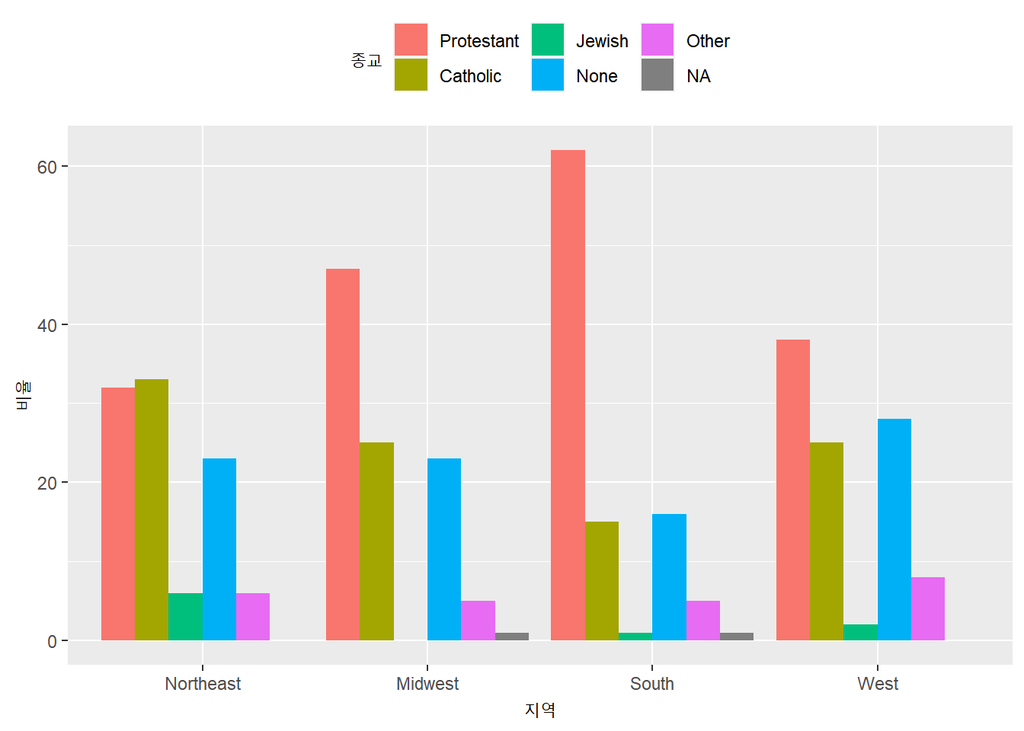

```r
p <- ggplot(rel_by_region, aes(x = bigregion, y = pct, fill = religion))
p + geom_col(position = "dodge") +
  labs(x = "지역", y = "비율", fill = "종교") +
  theme(legend.position = "top")
```

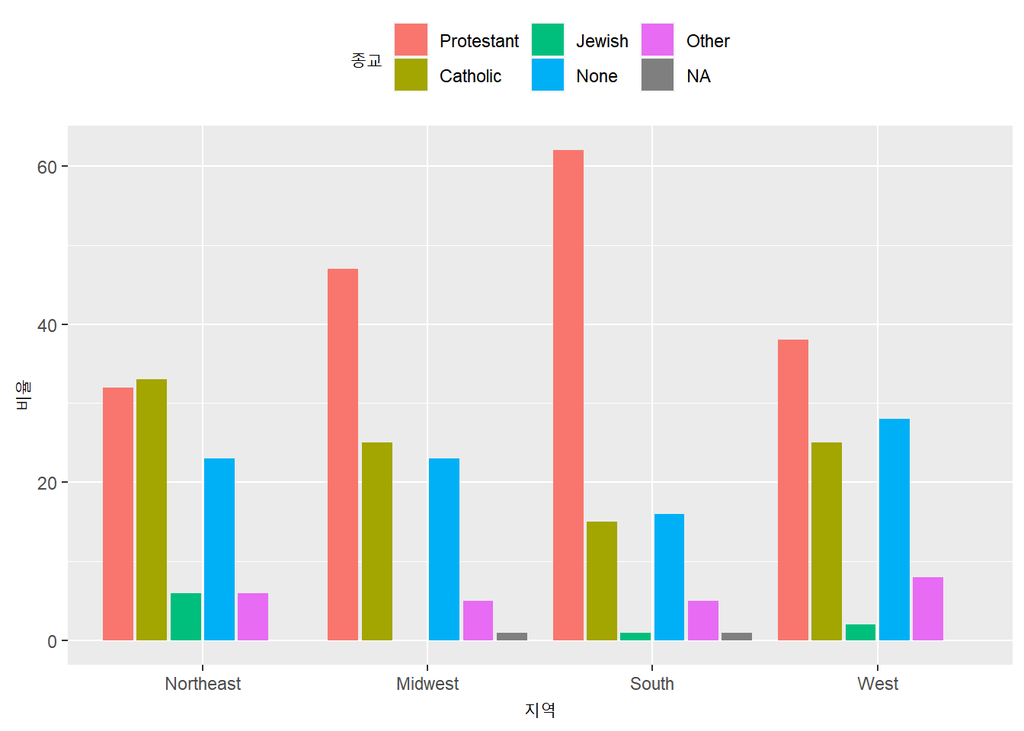

```r
p <- ggplot(rel_by_region, aes(x = bigregion, y = pct, fill = religion))
p + geom_col(position = "dodge2") +
  labs(x = "지역", y = "비율", fill = "종교") +
  theme(legend.position = "top")
```

- dodge와 dodge2 인수의 차이점(여기서는 나타나지 않음)
- 일반적으로 닷지 막대 그래프는 분할(facet)도표로 좀 더 명확하게 표현될 수 있다. 패싯을 사용하면 범례가 필요없으므로 차트를 더 쉽게 읽을 수 있다.

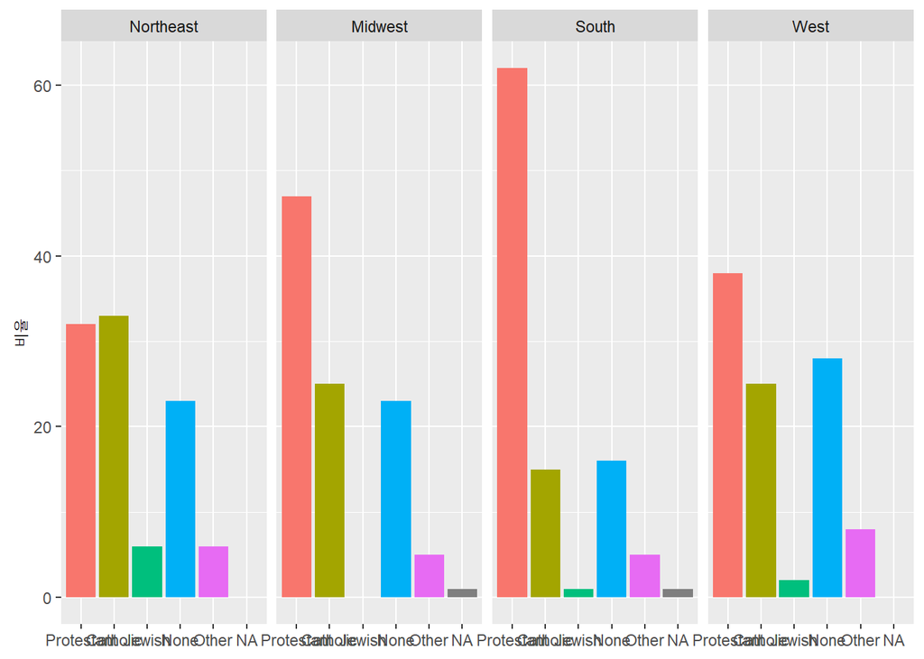

```r
p <- ggplot(rel_by_region, aes(x = religion, y = pct, fill = religion))
p + geom_col(position = "dodge2") +
  labs(x = NULL, y = "비율", fill = "Religion") +
  guides(fill = FALSE) +
#  coord_flip() +
  facet_grid(~ bigregion)
```

- 가로축의 종교명을 읽기 어려움. 이를 바꾸기 위해 ggplot의 aes의 x와 y의 매핑을 바꾸거나 coord_flip() 함수를 사용해 작업을 수행함
- ggplot 3.4.0 부터는 guides(fill = FALSE)를 사용하지 않음. 아래와 같이 guides(fill = “none”)으로 사용해야 함 It is now deprecated to specify guides( = FALSE) or scale_*(guide = FALSE) to remove a guide. Please use guides( = “none”) or scale_*(guide = “none”) instead (@yutannihilation, #4097)

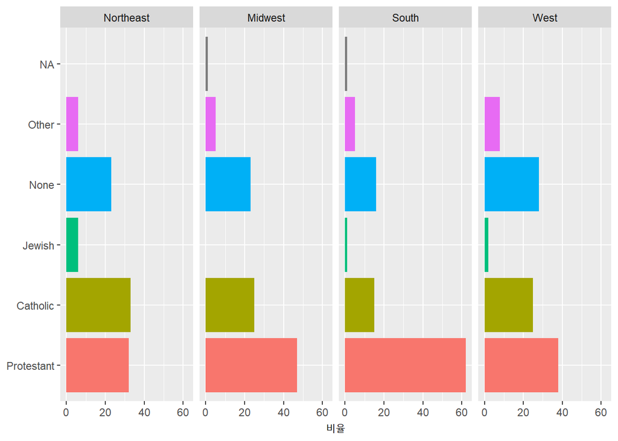

```r
# aes의 x, y 매핑 변경

p <- ggplot(rel_by_region, aes(y = religion, x = pct, fill = religion))
p + geom_col(position = "dodge2") +
  labs(y = NULL, x = "비율", fill = "Religion") +
  guides(fill = "none") +
#  coord_flip() +
  facet_grid(~ bigregion)
```

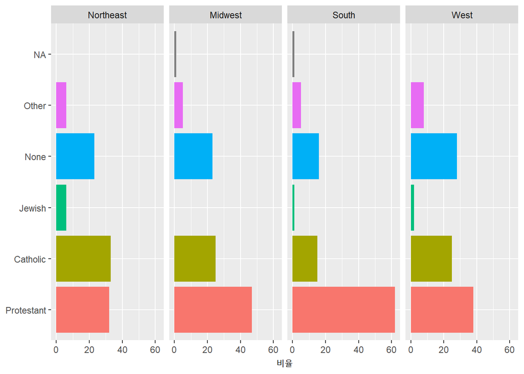

```r
# coord_flip() 함수 사용

p <- ggplot(rel_by_region, aes(x = religion, y = pct, fill = religion))
p + geom_col(position = "dodge2") +
  labs(x = NULL, y = "비율", fill = "Religion") +
  guides(fill = "none") +
  coord_flip() +
  facet_grid(~ bigregion)
```

- 대부분 도표의 경우 좌표계는 직교 좌표이며, x축과 y축으로 정의된 평면에 도표를 표시한다. `coord_cartesian()` 함수는 이를 관리하지만 호출할 필요는 없다.
- `coord_flip()` 함수는 도표가 만들어진 후 x축과 y축을 전환한다. (축을 전환하는 것이지 설정한 aes의 매핑을 바꾸지 않음)

## 5.2 그룹 또는 카테고리별 연속 변수

- 새로운 데이터셋인 organdata: gapminder와 마찬가지로 국가-연도(country-year)의 구조를 가지고 있음
- 17개 OECD 국가에서 이식용 장기 기증에 관한 10년 이상 가치 있는 정보가 포함되어 있음 (장기 조달률은 이식 수술에 사용하기 위해 시신 장기 기증자로부터 얻은 인간 장기의 수를 측정한 것)

```r
organdata %>% select(1:6) %>% sample_n(size = 10)
```

```
## # A tibble: 10 × 6
##    country       year       donors    pop pop_dens   gdp
##    <chr>         <date>      <dbl>  <int>    <dbl> <int>
##  1 Norway        1993-01-01   17.1   4312    1.33  21047
##  2 Denmark       1999-01-01   14.3   5322   12.4   26985
##  3 Belgium       1997-01-01   22.5  10181   30.8   22936
##  4 United States 2000-01-01   21.2 282224    2.93  34590
##  5 Canada        NA           NA    27701    0.278 19044
##  6 Germany       1994-01-01   12.3  81438   22.8   20690
##  7 Austria       1998-01-01   20.7   7977    9.51  25423
##  8 Canada        1991-01-01   14.7  28031    0.281 19101
##  9 Germany       2001-01-01   12.8  82350   23.1   25436
## 10 Norway        1999-01-01   15.5   4462    1.38  30005
```

기증자의 산점도를 연도별로 비교

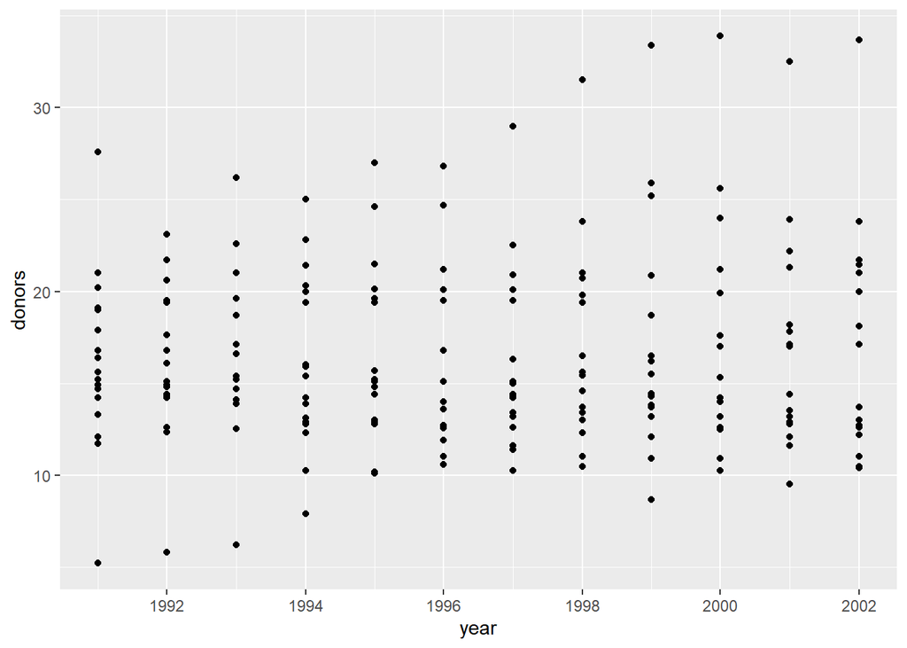

```r
p <- ggplot(data = organdata, mapping = aes(x = year, y = donors))
p + geom_point()
```

geom_line()을 사용해 각 국가의 시계열을 그릴 수 있음

- 이를 위해 ggplot에 그룹화 변수가 무엇인지 알려줘야 함
- 국가(범주)의 수가 너무 많지 않기 때문에 국가별 그림을 추가할 수 있음

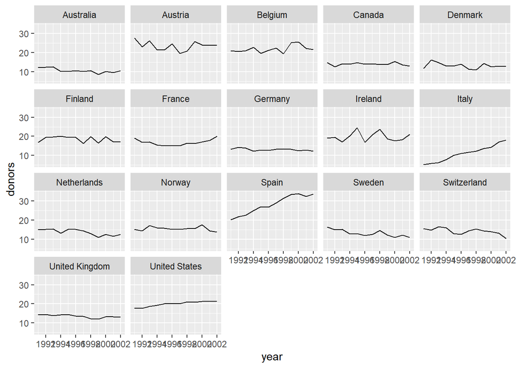

```r
p <- ggplot(data = organdata, mapping = aes(x = year, y = donors))
p + geom_line(aes(group = country)) + facet_wrap(~ country)
```

국가별 Box-plot 그리기

- geom_boxplot()을 사용해 국가별 연도별 변동 그림을 얻을 수 있다.
- 기본적으로 geom_bar()가 x에 매핑하는 카테고리에 의한 관측 수를 계산하는 것처럼 geom_boxplot()에서 작동하는 stat_boxplot()함수는 상자와 수염(whisker)을 그릴 수 있는 통계를 계산함
- geom_boxplot()은 분류할 변수(여기서는 country)와 요약하려는 연속 변수(여기서는 donors)를 말함

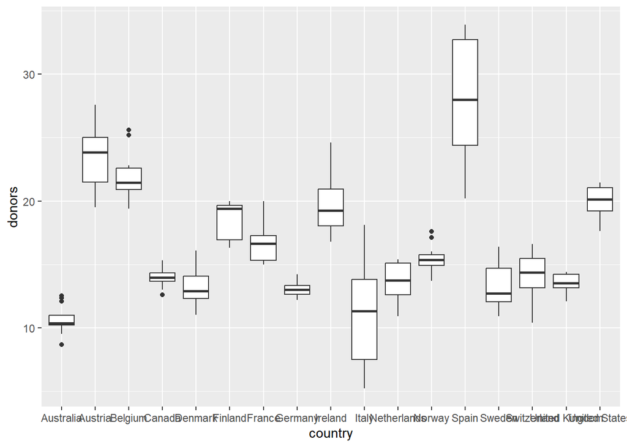

```r
p <- ggplot(data = organdata,
            mapping = aes(x = country, y = donors))
p + geom_boxplot()
```

축 전환

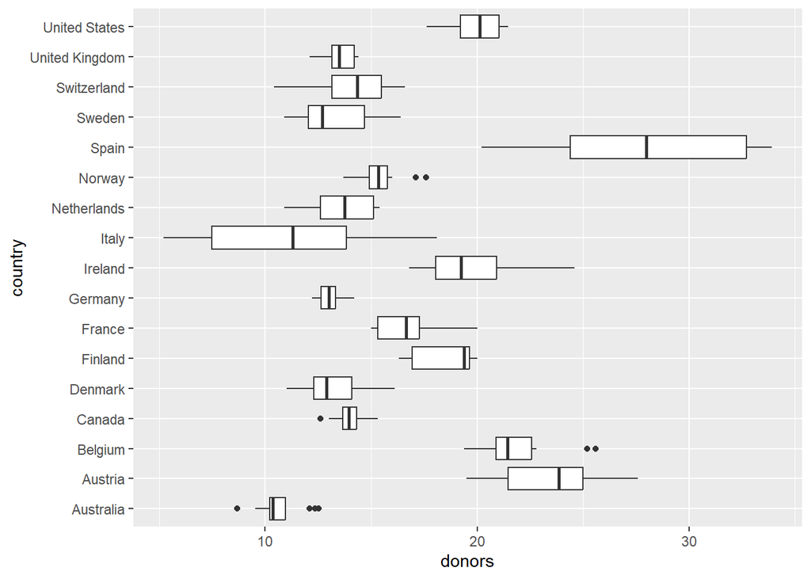

```r
p <- ggplot(data = organdata, mapping = aes(x = country, y = donors))
p + geom_boxplot() + coord_flip()
```

**평균 기증률이 높은 국가에서 낮은 국가순으로 나열**

- donors의 평균에 의해 country 변수를 재정렬함
- reorder() 함수가 다시 정렬하는 역할의 함수를 함
- R에서 평균을 구하려고 시도할 때 변수에 누락된 값이 있으면 기본 mean 함수를 이행하지 못하고 오류가 발생함
- 평균을 계산할 때 누락된 값을 제거해도 문제가 없다고 명시해야 함

  *`na.rm = TRUE` 인수를 reorder()에 제공해 내부적으로 mean()에 해당 인수를 전달*

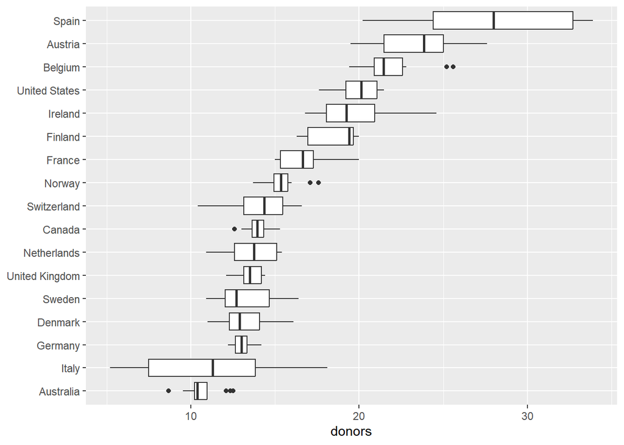

```r
p <- ggplot(data = organdata,
            mapping = aes(x = reorder(country, donors, na.rm = TRUE), y = donors))
p + geom_boxplot() + labs(x = NULL) + coord_flip()
```

geom_violin() 함수 사용

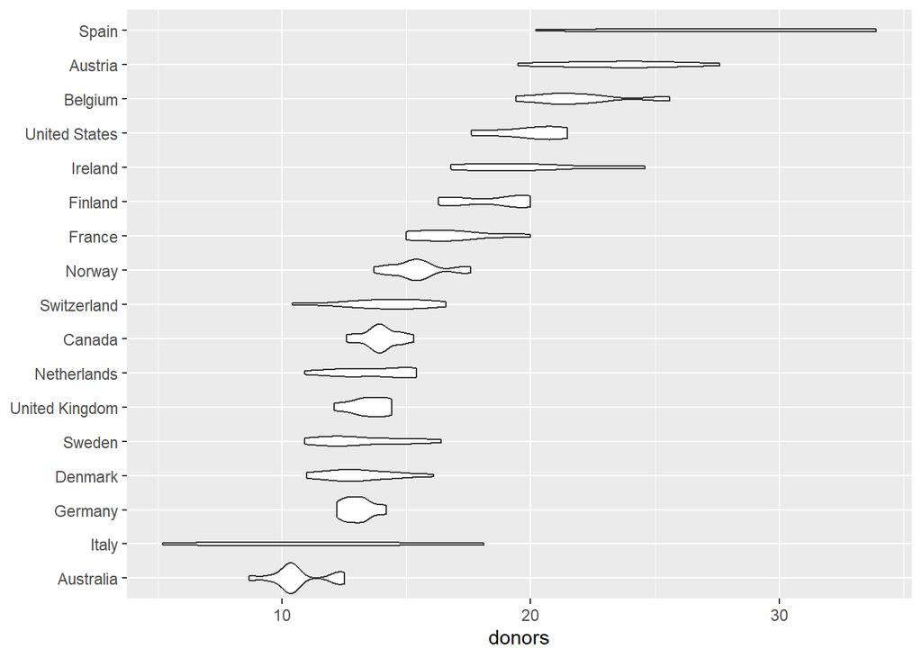

```r
p <- ggplot(data = organdata,
            mapping = aes(x = reorder(country, donors, na.rm = TRUE), y = donors))
p + geom_violin() + labs(x = NULL) + coord_flip()
```

박스플랏은 그림 5.9에서와 같이 color와 fill 값을 가져와 다른 geom과 같은 미학속성을 매핑할 수 있다.

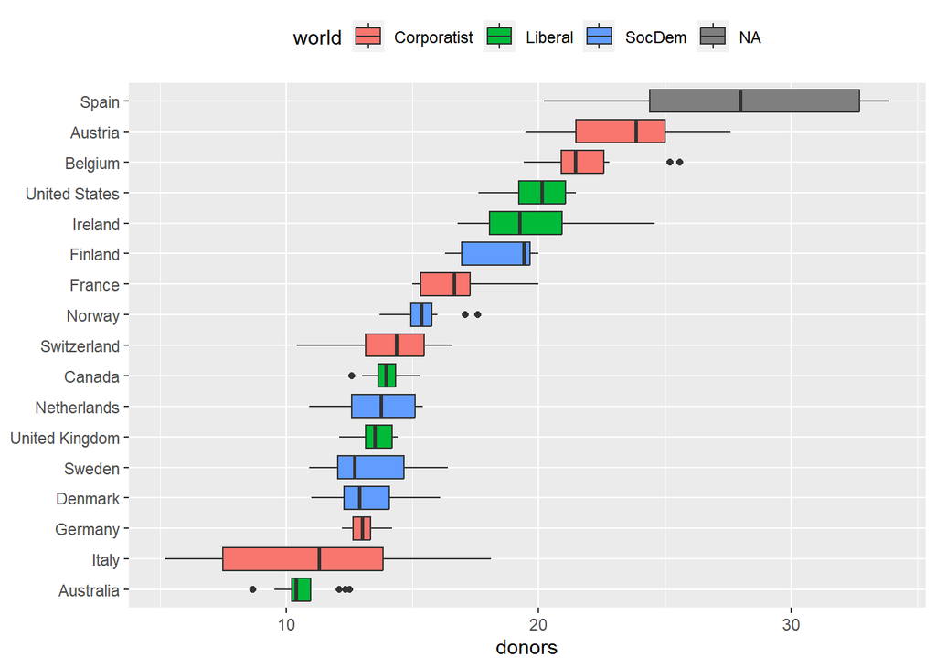

```r
p <- ggplot(data = organdata,
            mapping = aes(x = reorder(country, donors, na.rm = TRUE),
                          y = donors,
                          fill = world))
p + geom_boxplot() + labs(x = NULL) + coord_flip() + theme(legend.position = "top")
```

기본 geom_point() 플롯 모양은 fill이 아니라 color 속성을 갖기 때문에 fill 대신 world 변수로 채움

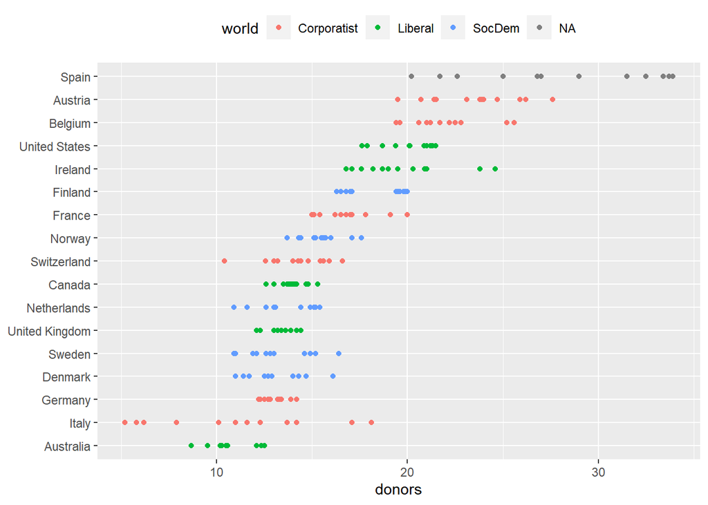

```r
p <- ggplot(data = organdata,
            mapping = aes(x = reorder(country, donors, na.rm = TRUE),
                          y = donors,
                          color = world))
p + geom_point() + labs(x = NULL) + coord_flip() + theme(legend.position = "top")
```

- geom_point()를 사용하면 관측값의 오버플로팅이 발생 -> 얼마나 많은 관측치가 있는지 더 잘 알려면 데이터를 조금 흩뜨려 놓는 geom_jitter()를 사용

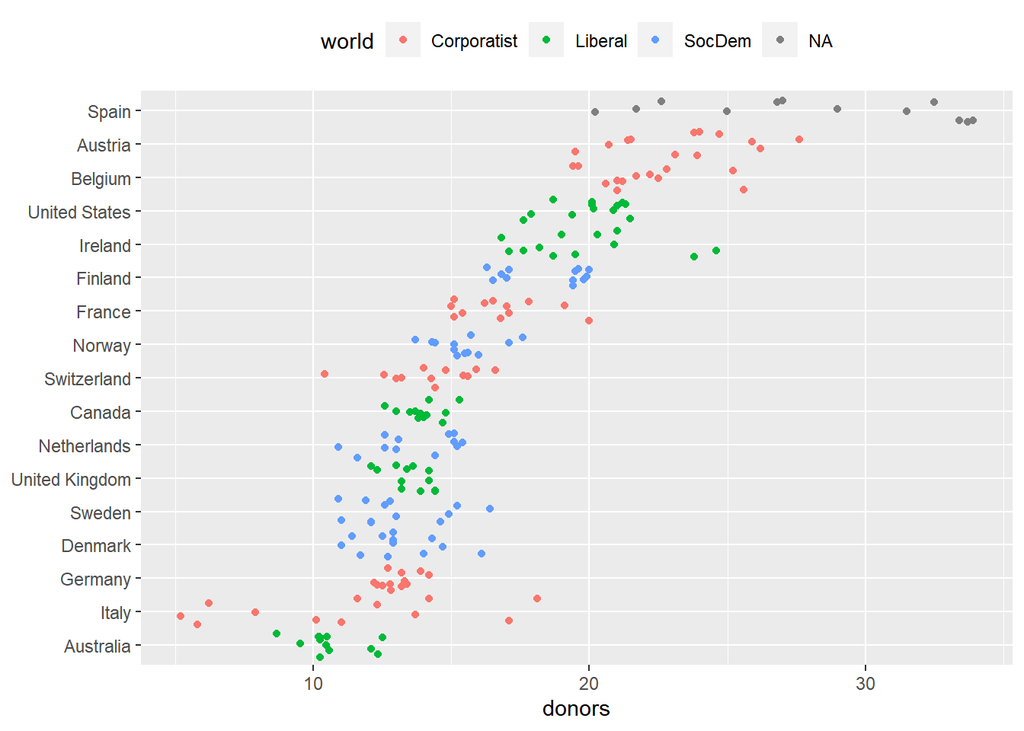

```r
p <- ggplot(data = organdata,
            mapping = aes(x = reorder(country, donors, na.rm = TRUE),
                          y = donors,
                          color = world))
p + geom_jitter() + labs(x = NULL) +
  coord_flip() +
  theme(legend.position = "top")
```

geom 내의 position_jitter() 함수에 대한 height와 width 인수 사용, 제어

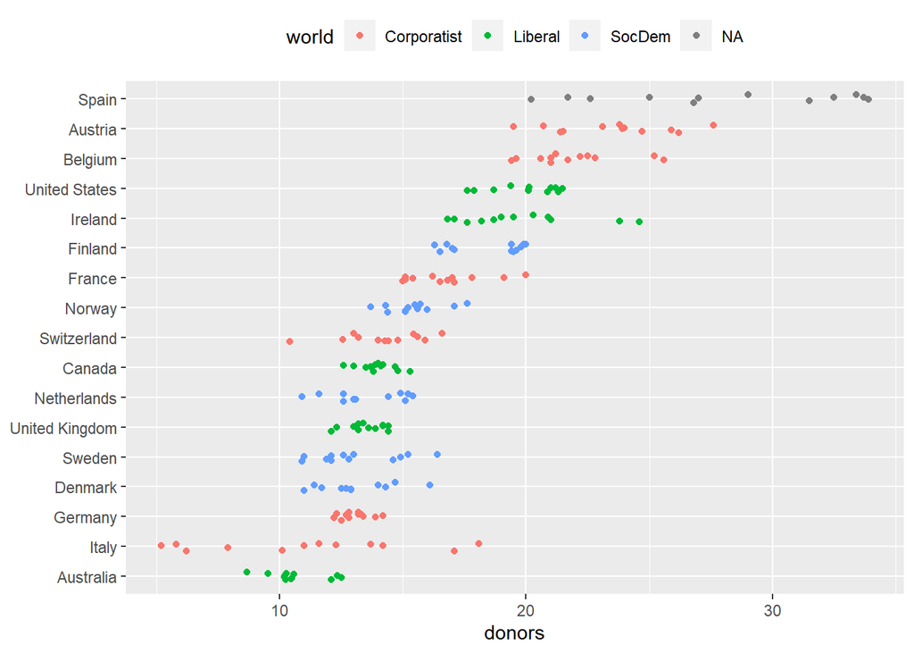

```r
p <- ggplot(data = organdata,
            mapping = aes(x = reorder(country, donors, na.rm = TRUE),
                          y = donors,
                          color = world))
p + geom_jitter(position = position_jitter(width = 0.15)) +
  labs(x = NULL) + coord_flip() + theme(legend.position = "top")
```

**클리블렌드 점도표(Cleveland dotplot)**

- 범주당 하나의 점을 갖는 범주형 변수를 요약하는 방법
- 막대 그래프 또는 테이블 보다 나은 데이터 표현 방법
- 파이프라인 이용 요약 통계량 생성

```r
by_country <- organdata %>% group_by(consent_law, country) %>%
  summarize(donors_mean = mean(donors, na.rm = TRUE),
            donors_sd = sd(donors, na.rm = TRUE),
            gdp_mean = mean(gdp, na.rm = TRUE),
            health_mean = mean(health, na.rm = TRUE),
            roads_mean = mean(roads, na.rm = TRUE),
            cerebvas_mean = mean(cerebvas, na.rm = TRUE))
by_country
```

```
## # A tibble: 17 × 8
## # Groups:   consent_law [2]
##    consent_law country        donors_m…¹ donor…² gdp_m…³ healt…⁴ roads…⁵ cereb…⁶
##    <chr>       <chr>               <dbl>   <dbl>   <dbl>   <dbl>   <dbl>   <dbl>
##  1 Informed    Australia            10.6   1.14   22179.   1958.   105.     558.
##  2 Informed    Canada               14.0   0.751  23711.   2272.   109.     422.
##  3 Informed    Denmark              13.1   1.47   23722.   2054.   102.     641.
##  4 Informed    Germany              13.0   0.611  22163.   2349.   113.     707.
##  5 Informed    Ireland              19.8   2.48   20824.   1480.   118.     705.
##  6 Informed    Netherlands          13.7   1.55   23013.   1993.    76.1    585.
##  7 Informed    United Kingdom       13.5   0.775  21359.   1561.    67.9    708.
##  8 Informed    United States        20.0   1.33   29212.   3988.   155.     444.
##  9 Presumed    Austria              23.5   2.42   23876.   1875.   150.     769.
## 10 Presumed    Belgium              21.9   1.94   22500.   1958.   155.     594.
## 11 Presumed    Finland              18.4   1.53   21019.   1615.    93.6    771.
## 12 Presumed    France               16.8   1.60   22603.   2160.   156.     433.
## 13 Presumed    Italy                11.1   4.28   21554.   1757    122.     712.
## 14 Presumed    Norway               15.4   1.11   26448.   2217.    70.0    662.
## 15 Presumed    Spain                28.1   4.96   16933    1289.   161.     655.
## 16 Presumed    Sweden               13.1   1.75   22415.   1951.    72.3    595.
## 17 Presumed    Switzerland          14.2   1.71   27233    2776.    96.4    424.
## # … with abbreviated variable names ¹donors_mean, ²donors_sd, ³gdp_mean,
## #   ⁴health_mean, ⁵roads_mean, ⁶cerebvas_mean
```

**summarize_if 사용**

```r
by_country2 <- organdata %>%
                group_by(consent_law, country) %>%
                summarize_if(is.numeric, list(mean, sd), na.rm = TRUE) %>%
                ungroup()
```

```r
by_country2
```

```
## # A tibble: 17 × 28
##    consent_law country   donor…¹ pop_fn1 pop_d…² gdp_fn1 gdp_l…³ healt…⁴ healt…⁵
##    <chr>       <chr>       <dbl>   <dbl>   <dbl>   <dbl>   <dbl>   <dbl>   <dbl>
##  1 Informed    Australia    10.6  18318.   0.237  22179.  21779.   1958.   1848.
##  2 Informed    Canada       14.0  29608.   0.297  23711.  23353.   2272.   2163.
##  3 Informed    Denmark      13.1   5257.  12.2    23722.  23275    2054.   1973.
##  4 Informed    Germany      13.0  80255.  22.5    22163.  21938.   2349.   2256.
##  5 Informed    Ireland      19.8   3674.   5.23   20824.  20154.   1480.   1341.
##  6 Informed    Netherla…    13.7  15548.  37.4    23013.  22554.   1993.   1885.
##  7 Informed    United K…    13.5  58187.  24.0    21359.  20962.   1561.   1464.
##  8 Informed    United S…    20.0 269330.   2.80   29212.  28699.   3988.   3760.
##  9 Presumed    Austria      23.5   7927.   9.45   23876.  23415.   1875.   1803.
## 10 Presumed    Belgium      21.9  10153.  30.7    22500.  22096.   1958.   1862.
## 11 Presumed    Finland      18.4   5112.   1.51   21019.  20763    1615.   1560.
## 12 Presumed    France       16.8  58056.  10.5    22603.  22211.   2160.   2066.
## 13 Presumed    Italy        11.1  57360.  19.0    21554.  21195.   1757    1689.
## 14 Presumed    Norway       15.4   4386.   1.35   26448.  25769.   2217.   2125.
## 15 Presumed    Spain        28.1  39666.   7.84   16933   16584.   1289.   1220.
## 16 Presumed    Sweden       13.1   8789.   1.95   22415.  22094    1951.   1868
## 17 Presumed    Switzerl…    14.2   7037.  17.0    27233   26931.   2776.   2656.
## # … with 19 more variables: pubhealth_fn1 <dbl>, roads_fn1 <dbl>,
## #   cerebvas_fn1 <dbl>, assault_fn1 <dbl>, external_fn1 <dbl>,
## #   txp_pop_fn1 <dbl>, donors_fn2 <dbl>, pop_fn2 <dbl>, pop_dens_fn2 <dbl>,
## #   gdp_fn2 <dbl>, gdp_lag_fn2 <dbl>, health_fn2 <dbl>, health_lag_fn2 <dbl>,
## #   pubhealth_fn2 <dbl>, roads_fn2 <dbl>, cerebvas_fn2 <dbl>,
## #   assault_fn2 <dbl>, external_fn2 <dbl>, txp_pop_fn2 <dbl>, and abbreviated
## #   variable names ¹donors_fn1, ²pop_dens_fn1, ³gdp_lag_fn1, ⁴health_fn1, …
```

```r
by_country3 <- organdata %>%
                group_by(consent_law, country) %>%
                summarize_if(is.numeric, funs(mean, sd), na.rm = TRUE) %>%
                ungroup()
by_country3
```

```
## # A tibble: 17 × 28
##    consent_law country   donor…¹ pop_m…² pop_d…³ gdp_m…⁴ gdp_l…⁵ healt…⁶ healt…⁷
##    <chr>       <chr>       <dbl>   <dbl>   <dbl>   <dbl>   <dbl>   <dbl>   <dbl>
##  1 Informed    Australia    10.6  18318.   0.237  22179.  21779.   1958.   1848.
##  2 Informed    Canada       14.0  29608.   0.297  23711.  23353.   2272.   2163.
##  3 Informed    Denmark      13.1   5257.  12.2    23722.  23275    2054.   1973.
##  4 Informed    Germany      13.0  80255.  22.5    22163.  21938.   2349.   2256.
##  5 Informed    Ireland      19.8   3674.   5.23   20824.  20154.   1480.   1341.
##  6 Informed    Netherla…    13.7  15548.  37.4    23013.  22554.   1993.   1885.
##  7 Informed    United K…    13.5  58187.  24.0    21359.  20962.   1561.   1464.
##  8 Informed    United S…    20.0 269330.   2.80   29212.  28699.   3988.   3760.
##  9 Presumed    Austria      23.5   7927.   9.45   23876.  23415.   1875.   1803.
## 10 Presumed    Belgium      21.9  10153.  30.7    22500.  22096.   1958.   1862.
## 11 Presumed    Finland      18.4   5112.   1.51   21019.  20763    1615.   1560.
## 12 Presumed    France       16.8  58056.  10.5    22603.  22211.   2160.   2066.
## 13 Presumed    Italy        11.1  57360.  19.0    21554.  21195.   1757    1689.
## 14 Presumed    Norway       15.4   4386.   1.35   26448.  25769.   2217.   2125.
## 15 Presumed    Spain        28.1  39666.   7.84   16933   16584.   1289.   1220.
## 16 Presumed    Sweden       13.1   8789.   1.95   22415.  22094    1951.   1868
## 17 Presumed    Switzerl…    14.2   7037.  17.0    27233   26931.   2776.   2656.
## # … with 19 more variables: pubhealth_mean <dbl>, roads_mean <dbl>,
## #   cerebvas_mean <dbl>, assault_mean <dbl>, external_mean <dbl>,
## #   txp_pop_mean <dbl>, donors_sd <dbl>, pop_sd <dbl>, pop_dens_sd <dbl>,
## #   gdp_sd <dbl>, gdp_lag_sd <dbl>, health_sd <dbl>, health_lag_sd <dbl>,
## #   pubhealth_sd <dbl>, roads_sd <dbl>, cerebvas_sd <dbl>, assault_sd <dbl>,
## #   external_sd <dbl>, txp_pop_sd <dbl>, and abbreviated variable names
## #   ¹donors_mean, ²pop_mean, ³pop_dens_mean, ⁴gdp_mean, ⁵gdp_lag_mean, …
```

- 파이프라인의 마지막 단계에서 데이터를 ungroup()해 결과가 평범한 티블이 되도록 함
- 모든 숫자가 요약됨 -> 요약된 수치값을 이용해 그래프 그리기(클리블랜드 점도표)

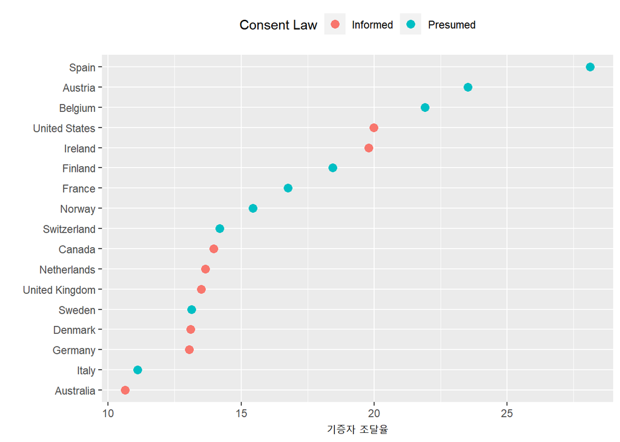

```r
p <- ggplot(data = by_country3,
            mapping = aes(x = donors_mean,
                          y = reorder(country, donors_mean),
                          color = consent_law))

p + geom_point(size = 3) +
  labs(x = "기증자 조달율",
       y = "",
       color = "Consent Law") +
  theme(legend.position = "top")
```

- 원한다면 점을 채색하는 대신 패싯을 사용할 수 있다. facet_wrap()을 사용해 consent_law 변수를 두 개의 패널로 나눈 다음 각 패널 내에서 기증률로 국가 순위를 매길 수 있다.

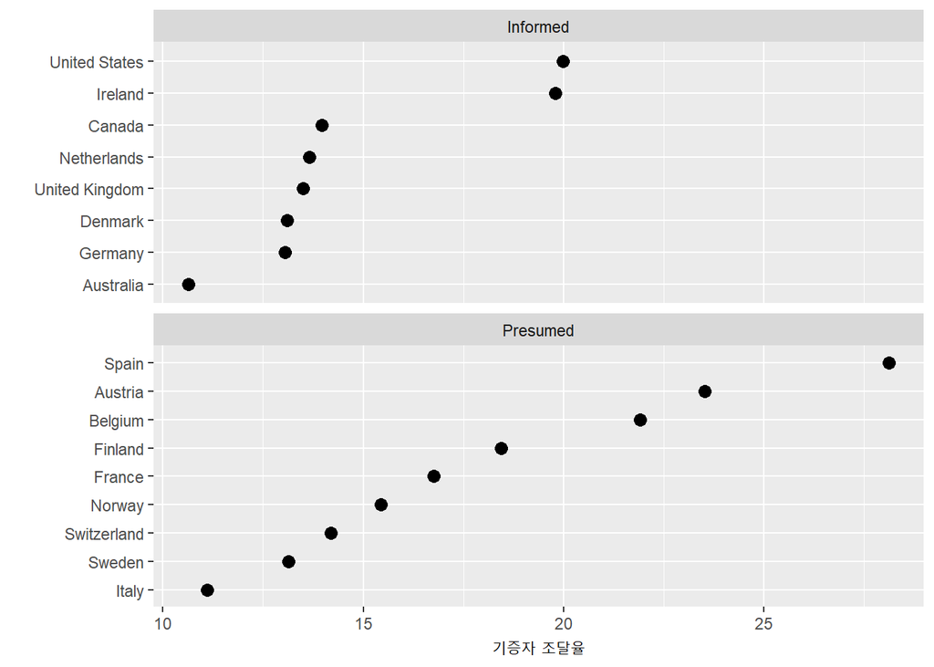

```r
p <- ggplot(data = by_country,
            mapping = aes(x = donors_mean,
                          y = reorder(country, donors_mean)))

p + geom_point(size = 3) +
  facet_wrap(~ consent_law, scales = "free_y", ncol = 1) +
  labs(x = "기증자 조달율", y = "")
```

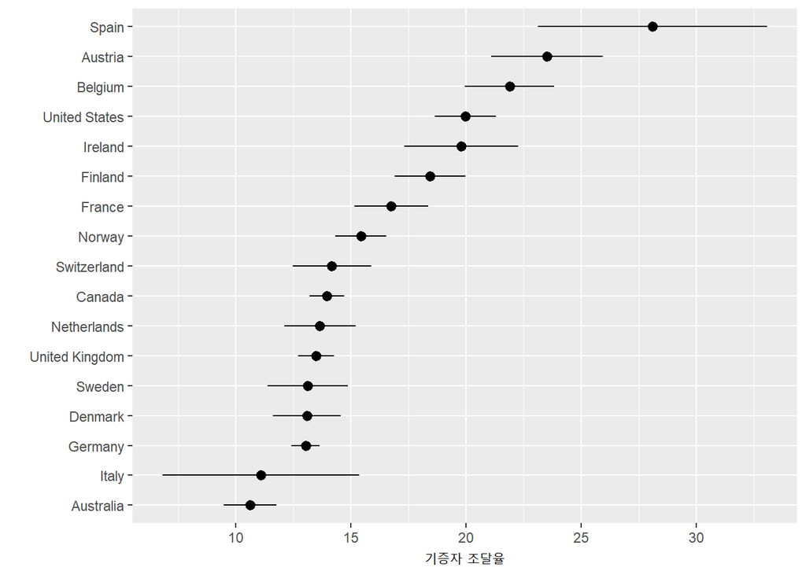

```r
p <- ggplot(data = by_country,
            mapping = aes(x = reorder(country, donors_mean),
                          y = donors_mean))

p + geom_pointrange(mapping = aes(ymin = donors_mean - donors_sd,
                                  ymax = donors_mean + donors_sd)) +
  labs(x = "", y ="기증자 조달율") + coord_flip()
```

## 5.3 텍스트를 직접 도표화하기

- 산점도와 함께 레이블을 나타내거나 유용한 레이블을 직접 도표화하는 것이 유용할 때가 있음.

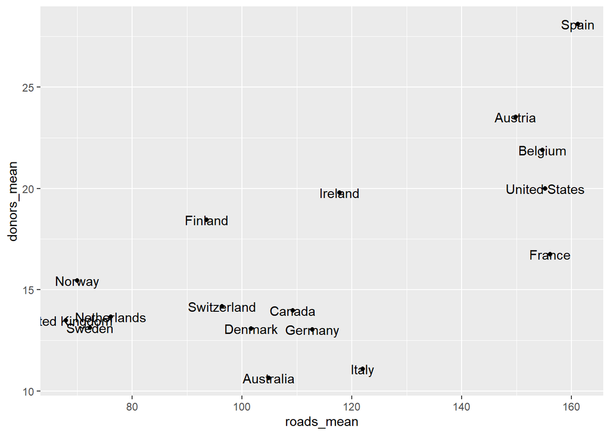

```r
p <- ggplot(data = by_country,
            mapping = aes(x = roads_mean,
                          y = donors_mean))

p + geom_point() + geom_text(mapping = aes(label = country))
```

- geom_text()에 hjust 인자를 사용해 레이블을 왼쪽 또는 오른쪽으로 정렬할 수 있음

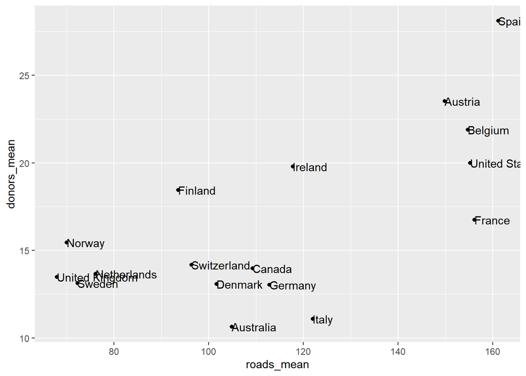

```r
p <- ggplot(data = by_country,
            mapping = aes(x = roads_mean, y = donors_mean))

p + geom_point() + geom_text(mapping = aes(label = country),
                             hjust = 0)
```

- geom_text()의 레이블의 미세 조정이 어렵거나, 이 때문에 발생하는 공간 변형 등을 방지하고자 한다면 ggrepel을 사용
- ggrepel 패키지는 geom_text_repel()과 geom_label_repel() 함수를 제공함 (이 두 함수는 geom_text()보다 훨씬 더 유연하게 레이블을 선택할 수 있음)

```r
library(ggrepel)
```

- geom_text_repel()이 수행할 수 있는 작업을 보여주기 위해 데이터셋을 전환

```r
elections_historic %>% select(2:7)
```

```
## # A tibble: 49 × 6
##     year winner                 win_party ec_pct popular_pct popular_margin
##    <int> <chr>                  <chr>      <dbl>       <dbl>          <dbl>
##  1  1824 John Quincy Adams      D.-R.      0.322       0.309        -0.104
##  2  1828 Andrew Jackson         Dem.       0.682       0.559         0.122
##  3  1832 Andrew Jackson         Dem.       0.766       0.547         0.178
##  4  1836 Martin Van Buren       Dem.       0.578       0.508         0.142
##  5  1840 William Henry Harrison Whig       0.796       0.529         0.0605
##  6  1844 James Polk             Dem.       0.618       0.495         0.0145
##  7  1848 Zachary Taylor         Whig       0.562       0.473         0.0479
##  8  1852 Franklin Pierce        Dem.       0.858       0.508         0.0695
##  9  1856 James Buchanan         Dem.       0.588       0.453         0.122
## 10  1860 Abraham Lincoln        Rep.       0.594       0.396         0.101
## # … with 39 more rows
```

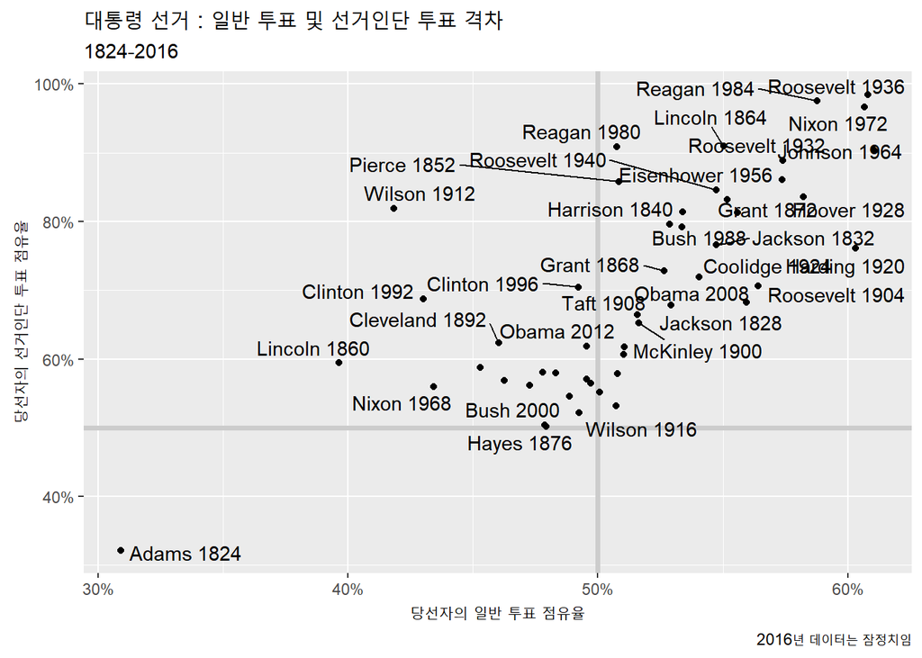

```r
p_title <- "대통령 선거 : 일반 투표 및 선거인단 투표 격차 "
p_subtitle <- "1824-2016"
p_caption <- "2016년 데이터는 잠정치임"
x_label <- "당선자의 일반 투표 점유율"
y_label <- "당선자의 선거인단 투표 점유율"

p <- ggplot(elections_historic, aes(x = popular_pct, y = ec_pct, label = winner_label))

p + geom_hline(yintercept = 0.5, size = 1.4, color = "gray80") +
    geom_vline(xintercept = 0.5, size = 1.4, color = "gray80") +
    geom_point() +
    geom_text_repel() +
    scale_x_continuous(labels = scales::percent) +
    scale_y_continuous(labels = scales::percent) +
    labs(x = x_label, y = y_label, title = p_title, subtitle = p_subtitle, caption = p_caption)
```

- 책의 저자는 geom_text() 보다 일반적으로 나은 선택이 될 것이라고 기술하고 있음

## 5.4 이상치 라벨링

- 때로는 모든 단일 항목에 레이블을 지정하지 않고 데이터에서 관심 있는 부분을 골라내고자 함
- geom_text_repel()에 geom_point()가 사용하는 것과 다른 데이터 셋을 사용하도록 지시(subset() 함수 사용)

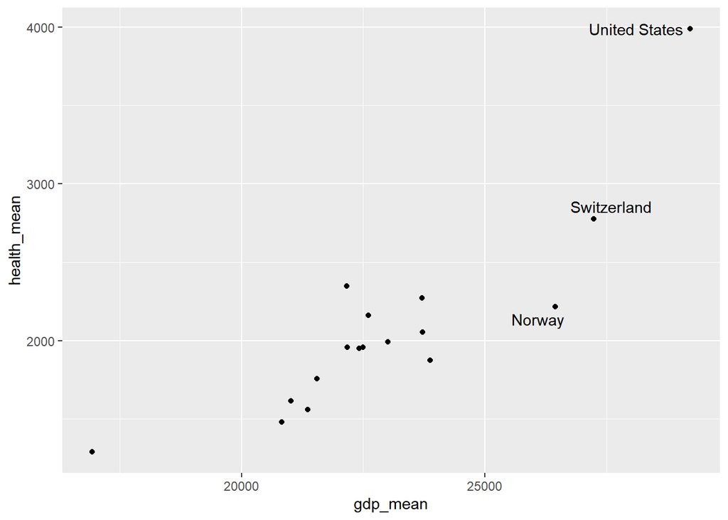

```r
p <- ggplot(data = by_country,
            mapping = aes(x = gdp_mean, y = health_mean))

p + geom_point() +
    geom_text_repel(data = subset(by_country, gdp_mean > 25000),
                    mapping = aes(label = country))
```

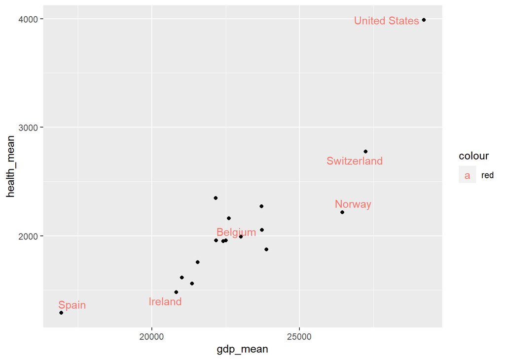

```r
p <- ggplot(data = by_country,
            mapping = aes(x = gdp_mean, y = health_mean))

p + geom_point() +
    geom_text_repel(data = subset(by_country,
                                  gdp_mean > 25000 | health_mean < 1500 | country %in% "Belgium"),
                    mapping = aes(label = country, colour = "red"))
```

```r
?geom_text_repel
```

```
## httpd 도움말 서버를 시작합니다 ... 완료
```

- 더미 변수를 이용한 라벨링 ccode가 Ita, Spa 이며 1998보다 큰 연도의 데이터에 TRUE index(더미값) 생성

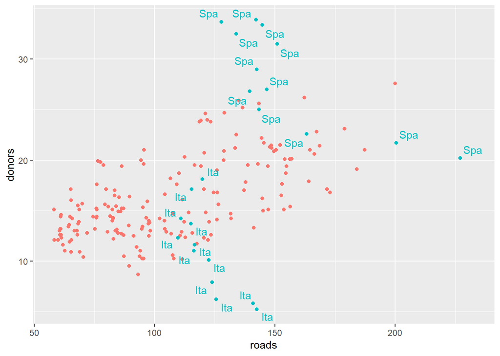

```r
organdata$ind <- organdata$ccode %in% c("Ita", "Spa") & organdata$year > 1998

p <- ggplot(data = organdata,
            mapping = aes(x = roads,
                          y = donors,
                          color = ind))

p + geom_point() +
    geom_text_repel(data = subset(organdata, ind),
                    mapping = aes(label = ccode)) +
    guides(label = FALSE, color = FALSE)
```

## 5.5 도표 영역에 쓰기와 그리기

- 그림에 직접 주석을 달 때는 annotate() 함수를 호출하여 사용

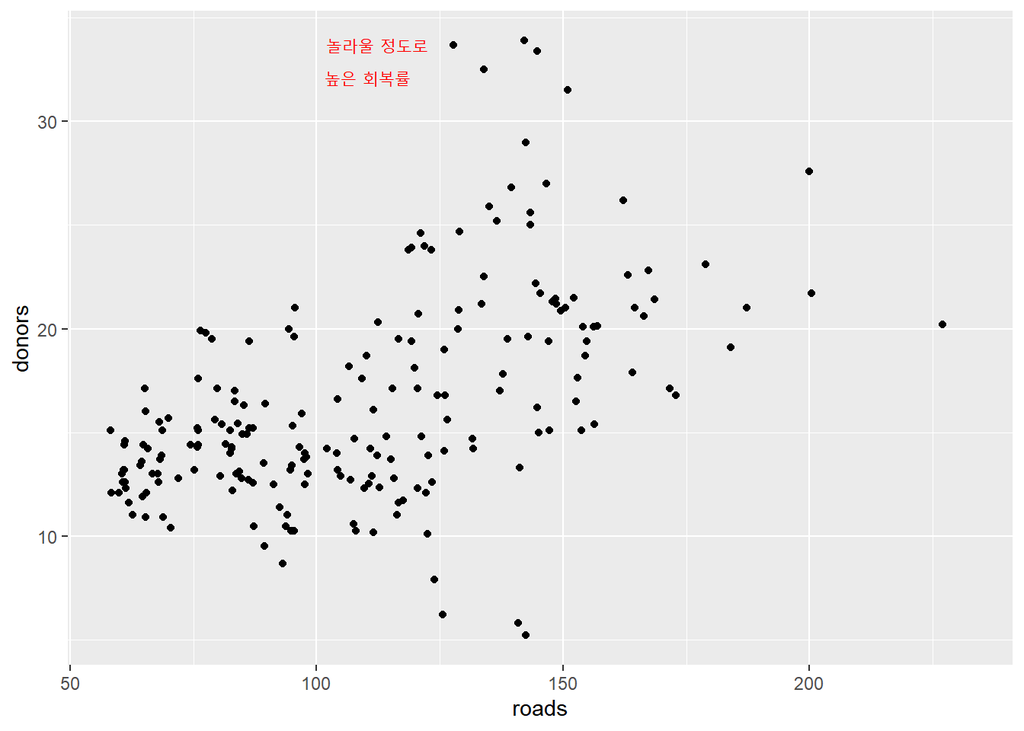

```r
p <- ggplot(data = organdata, mapping = aes(x = roads, y = donors))

p + geom_point() + annotate(geom = "text", x = 91, y =33,
                            label = "놀라울 정도로 \n 높은 회복률", hjust = -0.5, colour = "red")
```

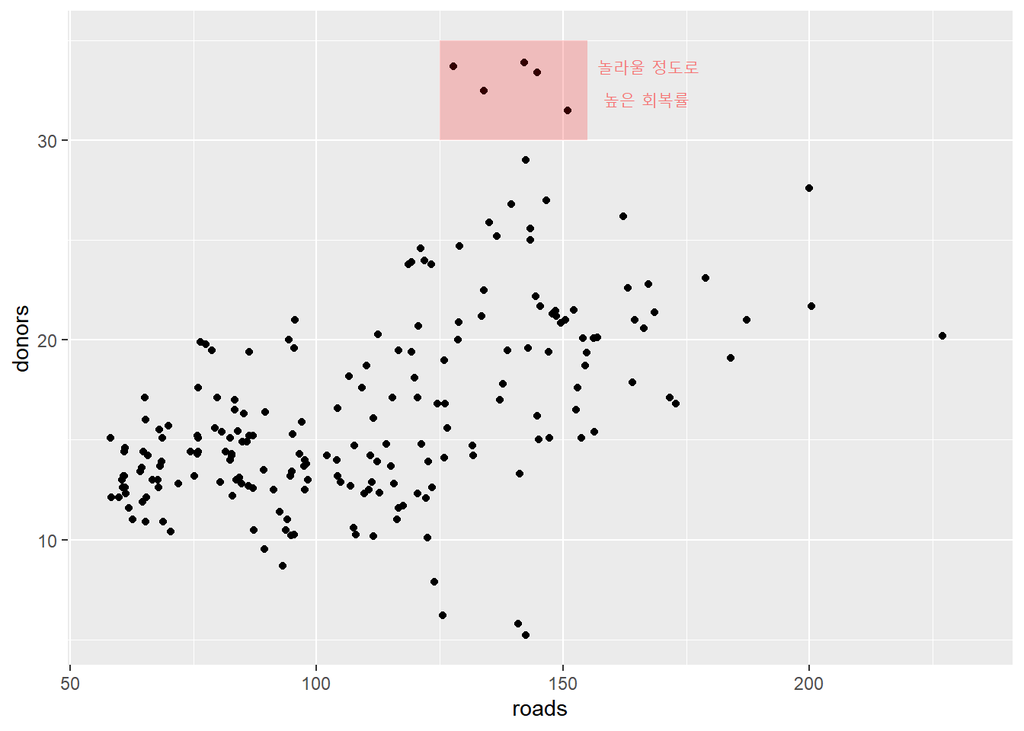

```r
p <- ggplot(data = organdata,
            mapping = aes(x = roads, y = donors))

p + geom_point() +
    annotate(geom = "rect", xmin = 125, xmax = 155,
             ymin = 30, ymax = 35, fill = "red", alpha = 0.2) +
    annotate(geom = "text", x = 157, y = 33,
             label = "놀라울 정도로 \n 높은 회복률", hjust = 0, colour = "red", alpha = 0.5)
```

## 5.6 척도, 가이드, 테마 이해하기

- 모든 미학적 매핑에는 척도가 있다. 해당 눈금 표시 또는 눈금 조정 방법을 조정하려면 scale_ 함수를 사용하라.
- 많은 척도에는 독자가 그래프를 해석하는 데 도움이 되는 범례나 키가 있다. 이들을 가이드라고 부른다. guides() 함수를 사용해 조정해 볼 수 있다. 아마도 가장 일반적인 용례는 때로는 필요가 없을 때 범례를 안보이도록 만드는 것이다.
- 그래프에는 표시되는 데이터의 논리적 구조에 엄격하게 연결되지 않은 다른 함수가 있다. 여기에는 배경색, 레이블에 사용된 폰트 또는 그래프에서 범례의 배치와 같은 것들이 포함된다. 이를 조정하려면 theme() 함수를 사용

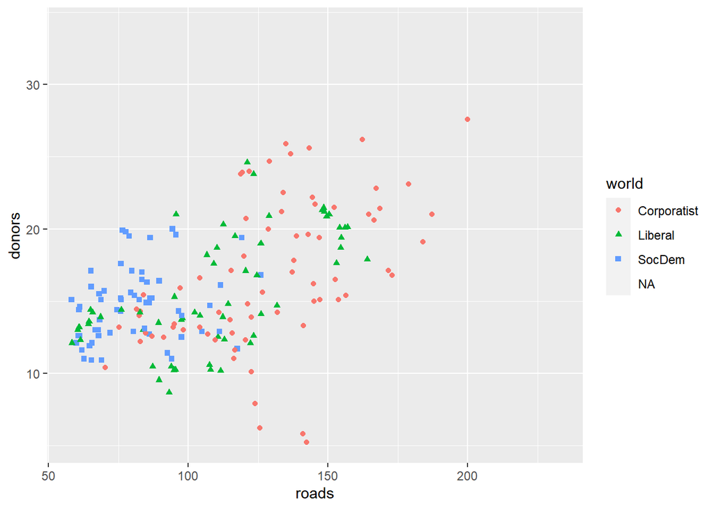

```r
p <- ggplot(data = organdata,
            mapping = aes(x = roads,
                          y = donors,
                          color = world,
                          shape = world))
p + geom_point()
```

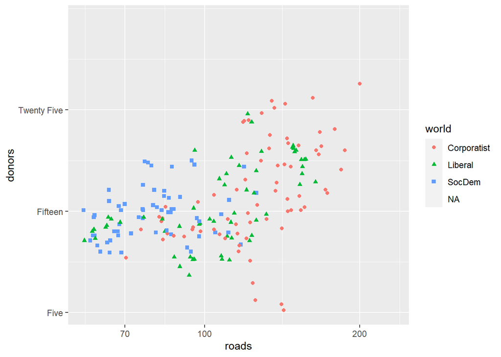

```r
p <- ggplot(data = organdata,
            mapping = aes(x = roads,
                          y = donors,
                          color = world,
                          shape = world))
p + geom_point() +
    scale_x_log10() +
    scale_y_continuous(breaks = c(5, 15, 25), labels = c("Five", "Fifteen", "Twenty Five"))
```

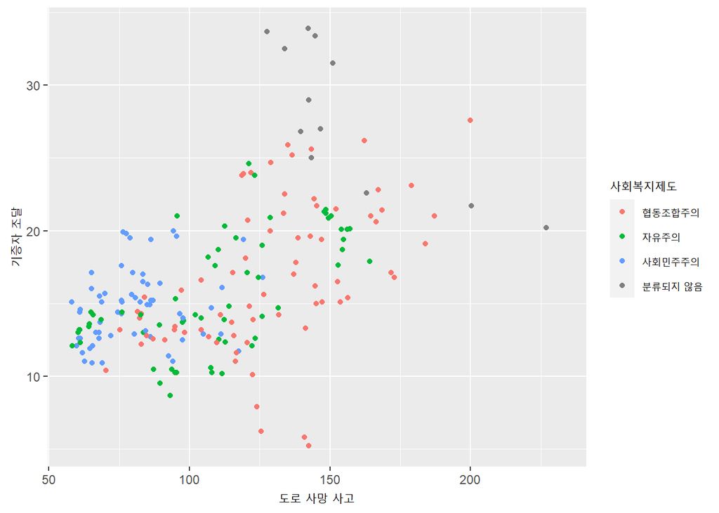

```r
p <- ggplot(data = organdata,
            mapping = aes(x = roads,
                          y = donors,
                          color = world))
p + geom_point() +
    scale_color_discrete(labels = c("협동조합주의", "자유주의", "사회민주주의", "분류되지 않음")) +
    labs(x = "도로 사망 사고", y = "기증자 조달", color = "사회복지제도")
```

- 가이드 삭제1

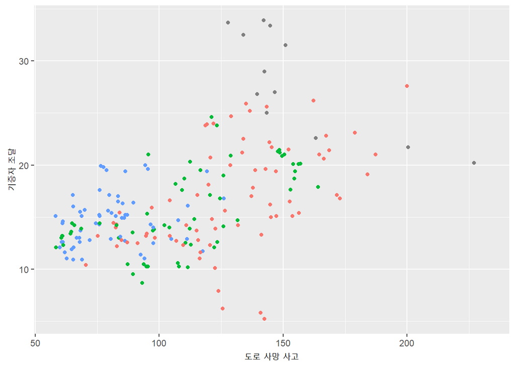

```r
p <- ggplot(data = organdata,
            mapping = aes(x = roads,
                          y = donors,
                          color = world))
p + geom_point() +
    labs(x = "도로 사망 사고", y = "기증자 조달", color = "사회복지제도") +
    guides(color = "none")
```

- 가이드 삭제2

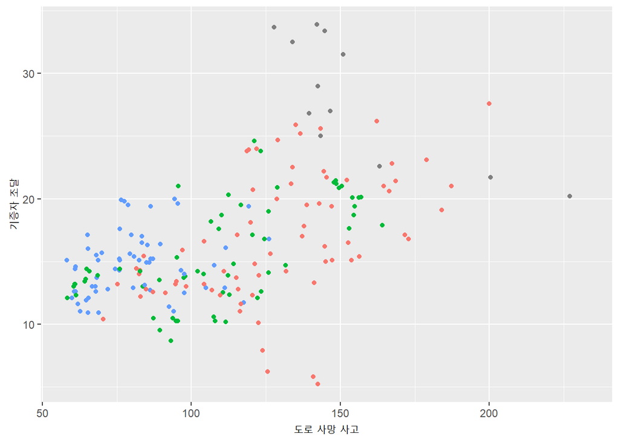

```r
p <- ggplot(data = organdata,
            mapping = aes(x = roads,
                          y = donors,
                          color = world))
p + geom_point() +
    labs(x = "도로 사망 사고", y = "기증자 조달", color = "사회복지제도") +
    guides(color = FALSE)
```

- 스케일 함수는 아래의 규칙으로 명명됨됨

```
scale_<매핑(mapping)>_<종류(kind)>()
```